# Topic 4 Exercises: Classification

# 4.7.11

```r
library(ISLR)
```

# a

```r
mpg01=rep(0, length(Auto$mpg))
mpg01[Auto$mpg>median(Auto$mpg)]=1
Auto=data.frame(Auto, mpg01)
```

# b

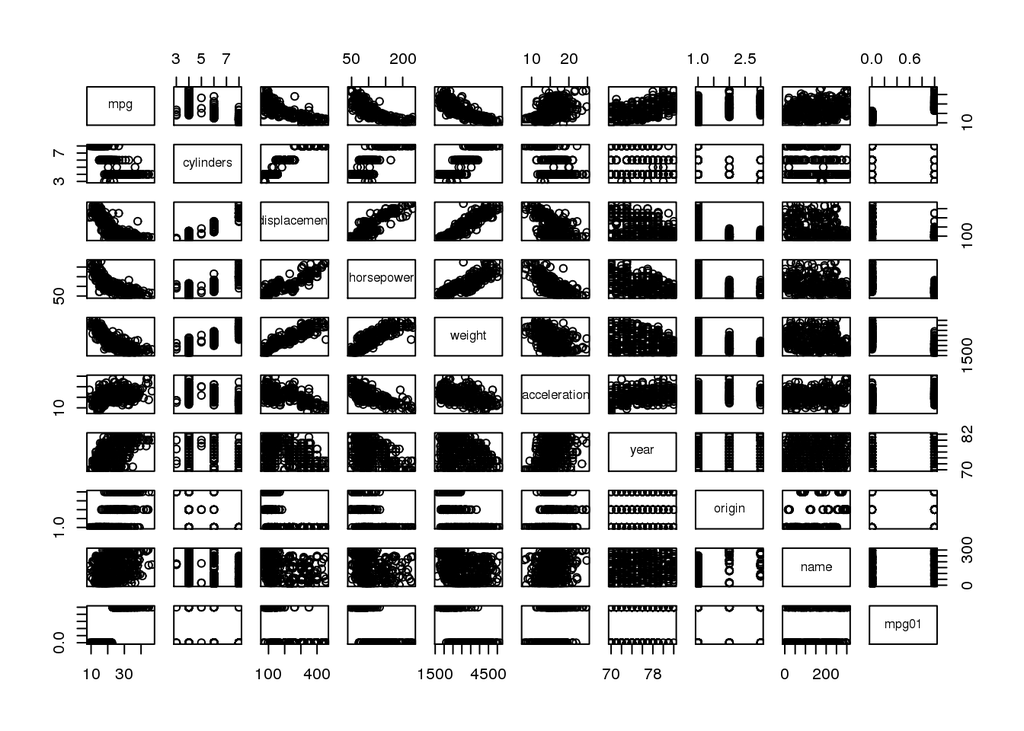

```r
pairs(Auto)
```

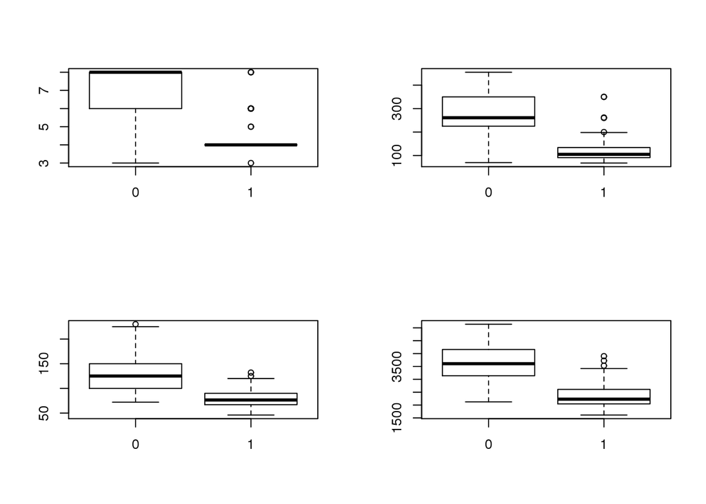

```r
par(mfrow=c(2,2))
boxplot(Auto$cylinders~Auto$mpg01)
boxplot(Auto$displacement~Auto$mpg01)
boxplot(Auto$horsepower~Auto$mpg01)
boxplot(Auto$weight~Auto$mpg01)
```

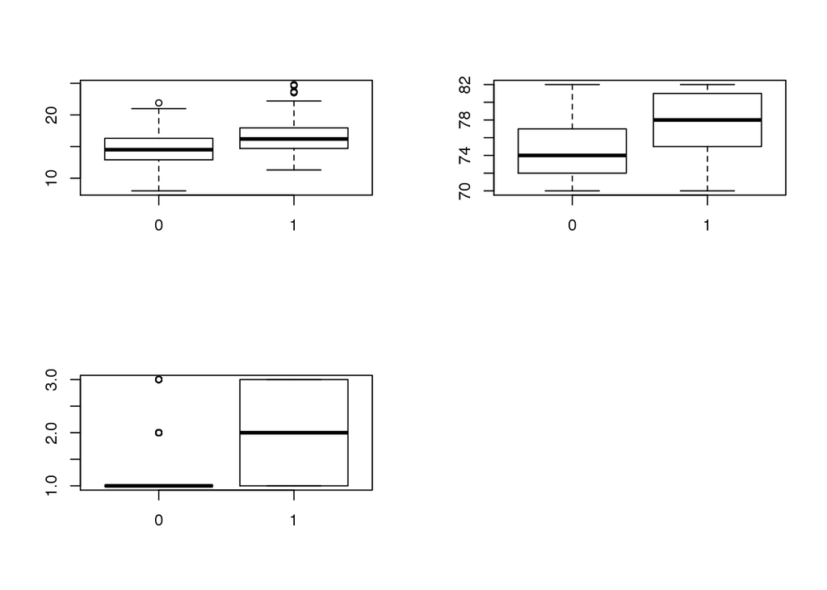

```r
boxplot(Auto$acceleration~Auto$mpg01)
boxplot(Auto$year~Auto$mpg01)
boxplot(Auto$origin~Auto$mpg01)
```

Based on this data cylinders, displacement, horsepower, and weight seem to have some effect on mpg01.

# c

```r
train=(Auto$year<77)
test=!train
Auto.test=Auto[test,]
Auto.train=Auto[train,]
mpg01.test=Auto$mpg01[test]
dim(Auto.test)
```

```
## [1] 178  10
```

# d

```r
library(MASS)
lda.fit=lda(mpg01 ~ cylinders+displacement+horsepower+weight,data=Auto, subset=train)
lda.pred=predict(lda.fit, Auto.test)
lda.class=lda.pred$class
mean(lda.class == mpg01.test)
```

```
## [1] 0.8932584
```

```r
1-mean(lda.class == mpg01.test)
```

```
## [1] 0.1067416
```

# e

```r
qda.fit=qda(mpg01 ~ cylinders+displacement+horsepower+weight,data=Auto, subset=train)
qda.class=predict(qda.fit, Auto.test)$class
mean(qda.class==mpg01.test)
```

```
## [1] 0.8651685
```

```r
1-mean(qda.class==mpg01.test)
```

```
## [1] 0.1348315
```

# f

```r
glm.fit=glm(mpg01 ~ cylinders+displacement+horsepower+weight, data=Auto, subset=train)
dim(Auto.test)
```

```
## [1] 178  10
```

```r
glm.probs=predict(glm.fit, Auto.test, type="response")

glm.pred=rep(0,181)
glm.pred[glm.probs>.5]=1

mean(glm.pred != mpg01.test)
```

```
## [1] 0.1049724
```

# g

```r
library(class)
train.X=cbind(Auto$cylinders, Auto$weight, Auto$displacement, Auto$horsepower)[train,]
test.X=cbind(Auto$cylinders, Auto$weight, Auto$displacement, Auto$horsepower)[!train,]
train.mpg01=Auto$mpg01[train]
set.seed(1)
knn.pred=knn(train.X, test.X, train.mpg01, k=1)
table(knn.pred, mpg01.test)
```

```
##         mpg01.test
## knn.pred  0  1
##        0 51 30
##        1  3 94
```

```r
mean(knn.pred!=mpg01.test)
```

```
## [1] 0.1853933
```

```r
knn.pred=knn(train.X, test.X, train.mpg01, k=5)
table(knn.pred, mpg01.test)
```

```
##         mpg01.test
## knn.pred   0   1
##        0  51  24
##        1   3 100
```

```r
mean(knn.pred!=mpg01.test)
```

```
## [1] 0.1516854
```

```r
knn.pred=knn(train.X, test.X, train.mpg01, k=10)
table(knn.pred, mpg01.test)
```

```
##         mpg01.test
## knn.pred  0  1
##        0 50 26
##        1  4 98
```

```r
mean(knn.pred!=mpg01.test)
```

```
## [1] 0.1685393
```

```r
knn.pred=knn(train.X, test.X, train.mpg01, k=30)
table(knn.pred, mpg01.test)
```

```
##         mpg01.test
## knn.pred  0  1
##        0 51 27
##        1  3 97
```

```r
mean(knn.pred!=mpg01.test)
```

```
## [1] 0.1685393
```

# 4.7.13

```r
library(MASS)
summary(Boston)
```

```
##       crim                zn             indus            chas
##  Min.   : 0.00632   Min.   :  0.00   Min.   : 0.46   Min.   :0.00000
##  1st Qu.: 0.08204   1st Qu.:  0.00   1st Qu.: 5.19   1st Qu.:0.00000
##  Median : 0.25651   Median :  0.00   Median : 9.69   Median :0.00000
##  Mean   : 3.61352   Mean   : 11.36   Mean   :11.14   Mean   :0.06917
##  3rd Qu.: 3.67708   3rd Qu.: 12.50   3rd Qu.:18.10   3rd Qu.:0.00000
##  Max.   :88.97620   Max.   :100.00   Max.   :27.74   Max.   :1.00000
##       nox               rm             age              dis
##  Min.   :0.3850   Min.   :3.561   Min.   :  2.90   Min.   : 1.130
##  1st Qu.:0.4490   1st Qu.:5.886   1st Qu.: 45.02   1st Qu.: 2.100
##  Median :0.5380   Median :6.208   Median : 77.50   Median : 3.207
##  Mean   :0.5547   Mean   :6.285   Mean   : 68.57   Mean   : 3.795
##  3rd Qu.:0.6240   3rd Qu.:6.623   3rd Qu.: 94.08   3rd Qu.: 5.188
##  Max.   :0.8710   Max.   :8.780   Max.   :100.00   Max.   :12.127
##       rad              tax           ptratio          black
##  Min.   : 1.000   Min.   :187.0   Min.   :12.60   Min.   :  0.32
##  1st Qu.: 4.000   1st Qu.:279.0   1st Qu.:17.40   1st Qu.:375.38
##  Median : 5.000   Median :330.0   Median :19.05   Median :391.44
##  Mean   : 9.549   Mean   :408.2   Mean   :18.46   Mean   :356.67
##  3rd Qu.:24.000   3rd Qu.:666.0   3rd Qu.:20.20   3rd Qu.:396.23
##  Max.   :24.000   Max.   :711.0   Max.   :22.00   Max.   :396.90
##      lstat            medv
##  Min.   : 1.73   Min.   : 5.00
##  1st Qu.: 6.95   1st Qu.:17.02
##  Median :11.36   Median :21.20
##  Mean   :12.65   Mean   :22.53
##  3rd Qu.:16.95   3rd Qu.:25.00
##  Max.   :37.97   Max.   :50.00
```

```r
crime01=rep(0, length(Boston$crim))
crime01[Boston$crim>median(Boston$crim)]=1
Boston=data.frame(Boston, crime01)
```

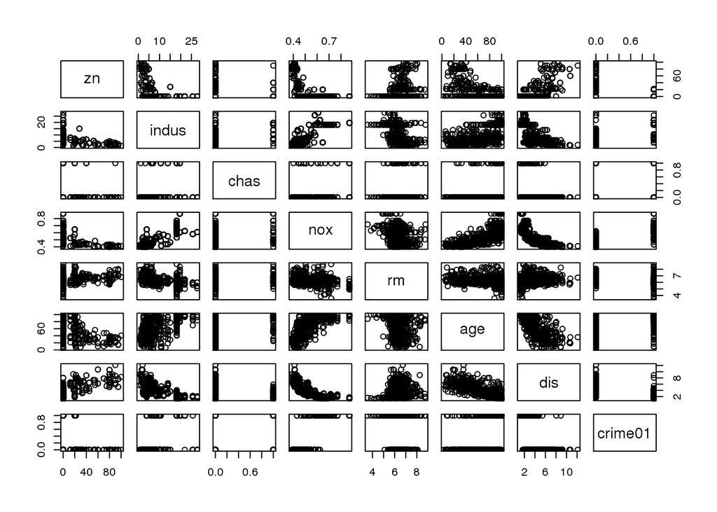

```r
pairs(~zn+indus+chas+nox+rm+age+dis+crime01,data=Boston)
```

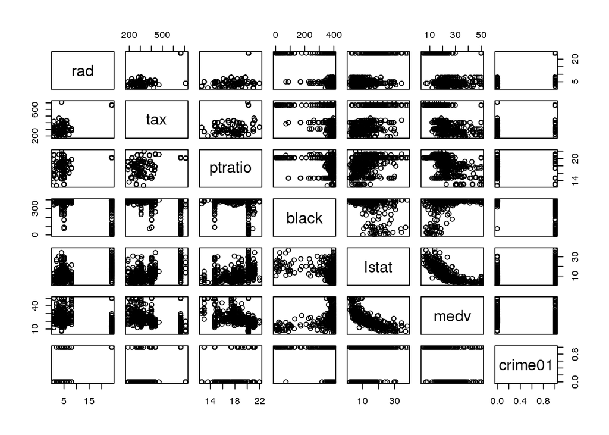

```r
pairs(~rad+tax+ptratio+black+lstat+medv+crime01,data=Boston)
```

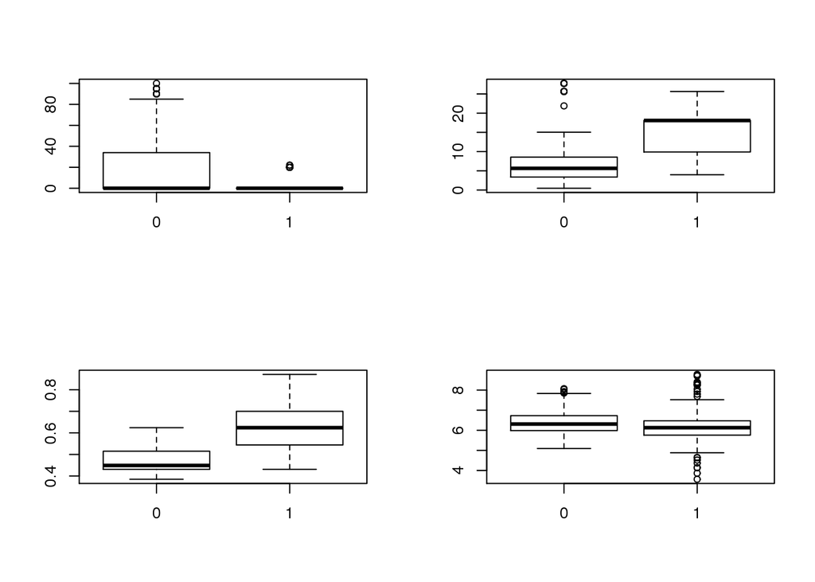

```r
par(mfrow=c(2,2))
boxplot(Boston$zn~Boston$crime01)
boxplot(Boston$indus~Boston$crime01)
boxplot(Boston$nox~Boston$crime01)
boxplot(Boston$rm~Boston$crime01)
```

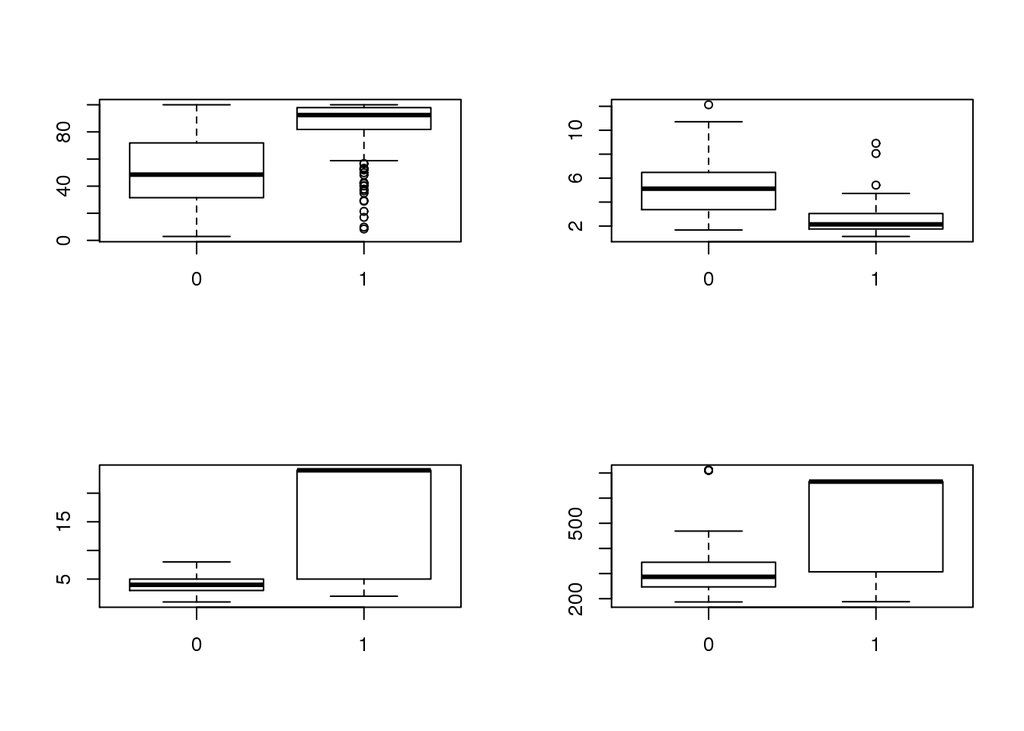

```r
boxplot(Boston$age~Boston$crime01)
boxplot(Boston$dis~Boston$crime01)
boxplot(Boston$rad~Boston$crime01)
boxplot(Boston$tax~Boston$crime01)
```

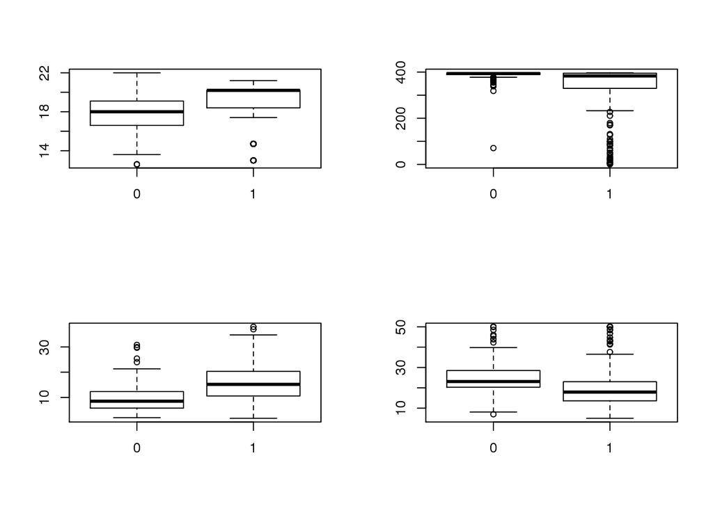

```r
boxplot(Boston$ptratio~Boston$crime01)
boxplot(Boston$black~Boston$crime01)
boxplot(Boston$lstat~Boston$crime01)
boxplot(Boston$medv~Boston$crime01)
```

```r
train=1:253
test=254:506
Boston.train=Boston[train,]
Boston.test=Boston[test,]
crime01.test=crime01[test]
```

```r
library(MASS)
lda.fit=lda(crime01 ~ indus+nox+tax,data=Boston, subset=train)
lda.pred=predict(lda.fit, Boston.test)
lda.class=lda.pred$class
mean(lda.class == crime01.test)
```

```
## [1] 0.8893281
```

```r
print("lda error")
```

```
## [1] "lda error"
```

```r
1-mean(lda.class == crime01.test)
```

```
## [1] 0.1106719
```

```r
qda.fit=qda(crime01 ~ indus+nox+tax,data=Boston, subset=train)
qda.class=predict(qda.fit, Boston.test)$class
mean(qda.class==crime01.test)
```

```
## [1] 0.3952569
```

```r
print("qda error")
```

```
## [1] "qda error"
```

```r
1-mean(qda.class==crime01.test)
```

```
## [1] 0.6047431
```

```r
glm.fit=glm(crime01 ~ indus+nox+tax,data=Boston, subset=train)
dim(Boston.test)
```

```
## [1] 253  15
```

```r
glm.probs=predict(glm.fit, Boston.test, type="response")

glm.pred=rep(0,253)
glm.pred[glm.probs>.5]=1

mean(glm.pred != crime01.test)
```

```
## [1] 0.1106719
```

```r
library(class)
train.X=cbind(Boston$indus,Boston$nox,Boston$tax)[train,]
test.X=cbind(Boston$indus,Boston$nox,Boston$tax)[test,]
train.crime01=Boston$crime01[train]
set.seed(1)
knn.pred=knn(train.X, test.X, train.crime01, k=1)
table(knn.pred, crime01.test)
```

```
##         crime01.test
## knn.pred   0   1
##        0  88 163
##        1   2   0
```

```r
mean(knn.pred!=crime01.test)
```

```
## [1] 0.6521739
```

```r
knn.pred=knn(train.X, test.X, train.crime01, k=10)
table(knn.pred, crime01.test)
```

```
##         crime01.test
## knn.pred   0   1
##        0  76  21
##        1  14 142
```

```r
mean(knn.pred!=crime01.test)
```

```
## [1] 0.1383399
```

```r
knn.pred=knn(train.X, test.X, train.crime01, k=50)
table(knn.pred, crime01.test)
```

```
##         crime01.test
## knn.pred   0   1
##        0  59  17
##        1  31 146
```

```r
mean(knn.pred!=crime01.test)
```

```
## [1] 0.1897233
```

When selecting indus, nox, and tax as our associated predictors LDA and logistic regesssion have the lowest test errors.

# 4.7.1

If we substitute A for e^B0+B1X then (4.2) is p(X)=A/1+A and (4.3) is p(X)/1-p(X)=A. We can then substitute A/1+A for p(X) in (4.3), making it (A/1+A)/1-(A/1+A) which can be rewritten as (A/1+A)*(1/(1-(A/1+A)). Then by multiplying by (1+A/1+A) we get A/(1+A)*(1+A)/(1+A-A) which simplifies to A.

# 4.7.8

While the average test score for the logistic regression is higher than the nearest neighbors method. It is very likely this low average is due to a low training error. Since it is 1-nearest neighboor test error is likely to be around 1% meaning the test error is near 36%. Because this method often over fits the data it is more likely to fail when applied than less flexible methods.

# 4.7.9

# a

.37=1.37*p(X) p(X)=0.270 27 of 100 people

# b

.16/(1-.16)=0.190